# Estrategias evolutivas

# Introducción

Los algoritmos del área de la computación evolutiva tratan de resolver problemas de diversa índole sin que se necesite asumir demasiadas hipótesis para su aplicación. Los algoritmos más clásicos de métodos numéricos para la resolución de problemas de optimización suelen tener unas hipótesis asociadas que en la práctica son difíciles de cumplir. Por ejemplo, el algoritmo del descenso del gradiente exige que la función sobre la que se aplique sea diferenciable. Otras hipótesis pueden ser la concavidad o convexidad, continuidad, problemas con los mínimos o máximos locales, etcétera.

Sin embargo, en funciones que pueden ser muy complejas o en problemas en los que se modelice la realidad, es frecuente que estas hipótesis no puedan aplicarse y, por tanto, haya que buscar algoritmos lo más *agnósticos* posibles. Es el caso de las estrategias evolutivas.

# Definición del problema

El objetivo es el de evaluar el comportamiento de estrategias evolutivas en la optimización de:

- **función suma de powell**.
- **función Nº4 de Xin-She Yang**.

Estas dos funciones son lo suficientemente complejas como para que no se puedan aplicar algoritmos habituales de métodos numéricos.

## Función suma de Powell

La función suma de Powel está definida por la expresión

$$f(\bar{x}) = \sum_{i = 1}^n |x_i|^{i+1}$$

donde $\bar{x} = (x_1, x_2, \ldots, x_n)$, siendo $-1 \leq x_i \leq 1$, $i = 1, \ldots,n$. Esta función tiene como propiedades ser:

- multi-dimensional
- continua
- convexa
- no-diferenciable
- unimodal

Podemos representar la función en el caso en el que $\bar{x} \in \mathbb{R}^2$.

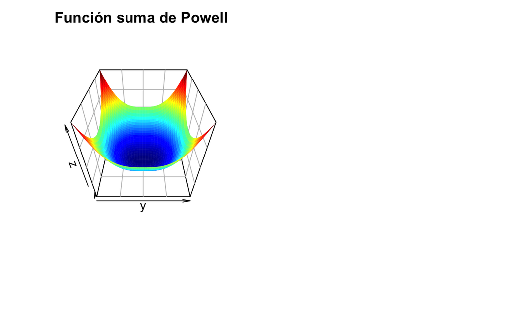

Esta función presenta un mínimo global que se alcanza en $\bar{x}^* = (0,0)$ tomando $f(\bar{x}^* ) = 0$.

## Función Nº 4 de Xin-She Yang

La función Nº 4 de Xin-She Yang tiene como expresión

$$f(\bar{x}) = \left( \sum_{i=1}^n sin^2(x_i) - exp\left(-\sum_{i=1}^nx_i^2\right)\right)\cdot exp\left(-\sum_{i=1}^nsin^2(\sqrt{|x_i|})\right)$$

Esta función es:

- No convexa.
- No diferenciable.

[figure not shown]

En el caso de $\mathbb{R}^2$, se ve que existe una gran cantidad de mínimos locales pero solo un mínimo global que se alcanza en $\bar{x}^* = (0,0)$ tomando $f(\bar{x}^* ) = -1$.

# Descripción de Estrategia Evolutiva

# Discusión de resultados

A continuación se detallan los resultados obtenidos al aplicar los algoritmos de estrategias evolutivas sobre las funciones de suma de Powell y la Nº 4 de Xin-She Yang.

Ambas funciones se atacarán sobre un espacio de dimensión $5$, es decir, se tratará de resolver el problema
$$argmin \,f(\bar{x})$$

tal que $\bar{x} = (x_1, \ldots, x_5)$.

Las estrategias evolutivas, como la gran mayoría del algoritmos utilizados para la optimización, llevan asociadas una serie de parámetros y configuraciones que pueden cambiar, por ejemplo, la eficiencia con la que se resuelva el problema. En nuestro caso, se va a abordar el problema con las siguientes configuraciones:

- **Configuración 1:**
  - *Tipo de mutación:* no correlacionada de paso único.
  - *Selección de supervivientes*: $(\mu, \lambda) = (30, 200)$
- **Configuración 2:**
  - *Tipo de mutación:* no correlacionada de $n$ pasos.
  - *Selección de supervivientes*: $(\mu, \lambda) = (30, 200)$
- **Configuración 3:**
  - *Tipo de mutación:* no correlacionada de paso único.
  - *Selección de supervivientes*: $(\mu + \lambda) = (30 + 200)$
- **Configuración 4:**
  - *Tipo de mutación:* no correlacionada de $n$ pasos.
  - *Selección de supervivientes*: $(\mu + \lambda) = (30 + 200)$

Todas las configuraciones tendrán en común:

- $20$ ejecuciones independientes del algoritmo.
- $1000$ generaciones en cada ejecución.

Por supuesto, hay más parámetros que pueden intervenir en las estrategias evolutivas y que serán tratados también las ejecuciones.

## Función suma de Powell

### Configuración 1

Para esta ejecución, es necesario ejecutar el siguiente código conforme a la implementación realizada:

```r
param <- list(n.x = 5,
              n.sigma = 1,
              tam.poblacion = 30,

              x.min = -1,
              x.max = 1,

              sigma.min = 1,
              sigma.max = 10,

              num.iter = 1000,

              lambda = 200,
              mu = 30,
              estrategia = ",",
              min = TRUE,
              funcion = suma_powell,

              global = TRUE,
              recomb.x = "discreta",
              recomb.sigma = "discreta",

              tau1 = 1/sqrt(2*5),
              tau2 = 0,
              epsilon = 0.001
)

set.seed(123)
resultados <- replicate(20, estrategia_evolutiva(param), simplify = FALSE)
```

A continuación se muestra la **gráfica de progreso** obtenida de la ejecución del algoritmo, es decir, se representa una línea para cada una de las $20$ ejecuciones que pueda relacionar el menor valor de la función de fitness obtenido en cada iteración:

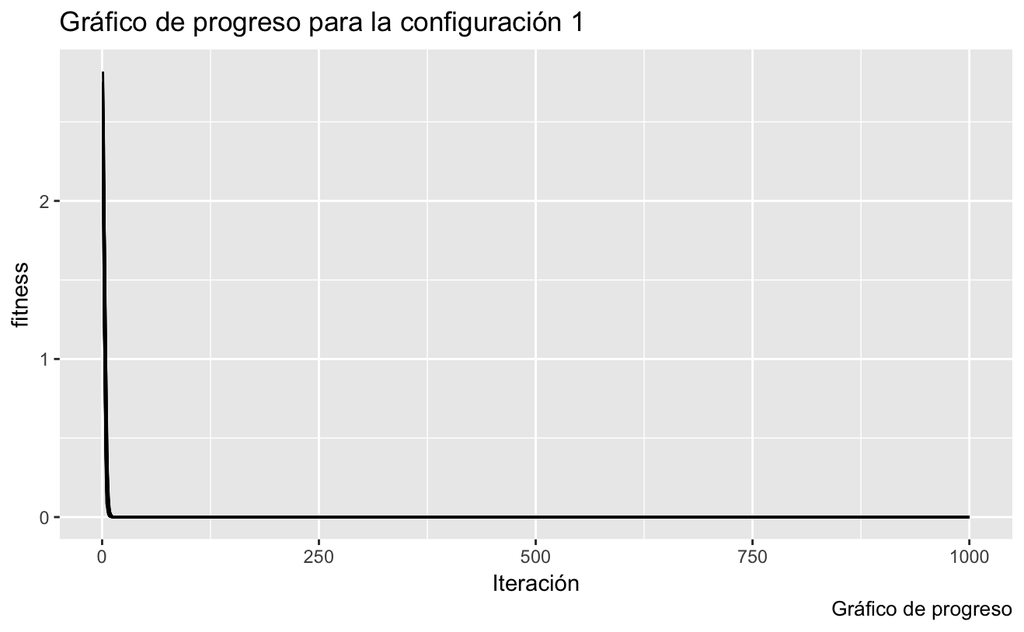

A la vista de este gráfico, se aprecia una disminución de la función de fitness bastante acusada en las primeras iteraciones. Sin embargo, la escala del gráfico dificulta obtener conclusiones. Si hacemos *zoom* sobre las 20 primeras iteraciones del algoritmo, comprobamos el abrupto descenso que sucede en las diez primeras.

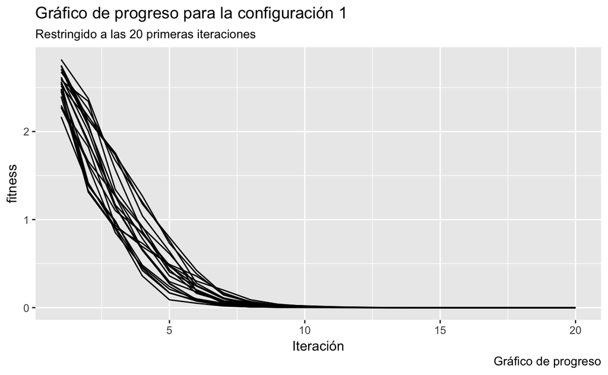

```r
resultados %>%
  filter(iteracion <= 20) %>%
  ggplot(aes(x = iteracion,
             y = fitness,
             group = id_ejecucion)) +
  geom_line() +
  labs(caption = "Gráfico de progreso",
       x = "Iteración",
       title = "Gráfico de progreso para la configuración 1",
       subtitle = "Restringido a las 20 primeras iteraciones")
```